# FIA - NLS Models: Biomass vs. Stand Age, G-Reconciled, Temporally-balanced, No harvest

## predict and plot

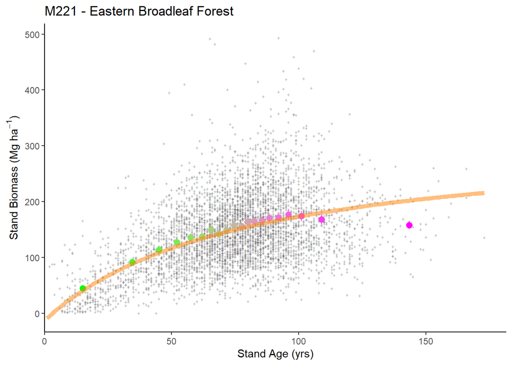

## plotting 2

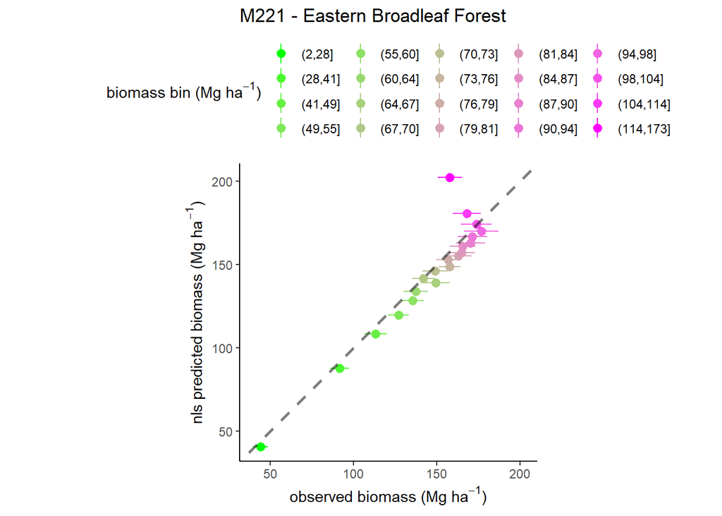

# M223 - Ozark Broadleaf Forest Meadow

## model selection 1

```
## Analysis of Variance Table
##
## Model 1: B_plt_t1_MgHa ~ (1 + (MEASTIME_t2 - 1990) * ge/100) * A * STDAGE_t2/(k + STDAGE_t2)
## Model 2: B_plt_t1_MgHa ~ (1 + (MEASTIME_t2 - 1990) * ge/100) * (1 + phi * DeltaPDSI) * A * STDAGE_t2/(k + STDAGE_t2)
## Model 3: B_plt_t1_MgHa ~ (1 + (MEASTIME_t2 - 1990) * ge/100) * (1 + phi * DeltaPDSI) * (1 - alpha * B_L_prop) * A * STDAGE_t2/(k + STDAGE_t2)
##   Res.Df Res.Sum Sq Df  Sum Sq F value    Pr(>F)
## 1    518     60.998
## 2    517     58.948  1 2.04975 17.9770 2.649e-05 ***
## 3    516     58.935  1 0.01356  0.1188    0.7305
## ---
## Signif. codes:  0 '***' 0.001 '**' 0.01 '*' 0.05 '.' 0.1 ' ' 1
##   model      AIC
## 1     1 5214.177
## 2     2 5198.369
## 3     3 5200.249
```

```
##
## Formula: B_plt_t1_MgHa ~ (1 + (MEASTIME_t2 - 1990) * ge/100) * (1 + phi *
##     DeltaPDSI) * A * STDAGE_t2/(k + STDAGE_t2)
##
## Parameters:
##      Estimate Std. Error t value Pr(>|t|)
## ge   -1.09922    0.20517  -5.358 1.27e-07 ***
## phi   0.09949    0.02512   3.960 8.54e-05 ***
## A   657.44582  192.13327   3.422 0.000671 ***
## k   255.91779   89.83169   2.849 0.004562 **
## ---
## Signif. codes:  0 '***' 0.001 '**' 0.01 '*' 0.05 '.' 0.1 ' ' 1
##
## Residual standard error: 0.3377 on 517 degrees of freedom
##
## Number of iterations to convergence: 6
## Achieved convergence tolerance: 1.56e-06
##   (1 observation deleted due to missingness)
```

### summary

- simple model: fits
- phi model: fits
- phi-alpha model: fits

## model selection 2

```
## Error in numericDeriv(form[[3L]], names(ind), env, central = nDcentral) :
##   Missing value or an infinity produced when evaluating the model
## Error in nls(get(paste("f_", Mod.Sel1, "c", sep = "")), data = G_M223,  :
##   step factor 0.000488281 reduced below 'minFactor' of 0.000976562
## Analysis of Variance Table
##
## Model 1: B_plt_t1_MgHa ~ (1 + (MEASTIME_t2 - 1990) * ge/100) * (1 + phi * DeltaPDSI) * A * STDAGE_t2/(k + STDAGE_t2)
## Model 2: B_plt_t1_MgHa ~ (1 + (MEASTIME_t2 - 1990) * ge/100) * (1 + phi * DeltaPDSI) * (p * A + ((1 - p) * A * STDAGE_t2/(k + STDAGE_t2)))
##   Res.Df Res.Sum Sq Df  Sum Sq F value  Pr(>F)
## 1    517     58.948
## 2    516     58.590  1 0.35866  3.1587 0.07611 .
## ---
## Signif. codes:  0 '***' 0.001 '**' 0.01 '*' 0.05 '.' 0.1 ' ' 1
##   model      AIC
## 1     2 5198.369
## 2    2a 5197.189
## 3    2b       NA
## 4    2c       NA
```

```
##
## Formula: B_plt_t1_MgHa ~ (1 + (MEASTIME_t2 - 1990) * ge/100) * (1 + phi *
##     DeltaPDSI) * (p * A + ((1 - p) * A * STDAGE_t2/(k + STDAGE_t2)))
##
## Parameters:
##      Estimate Std. Error t value Pr(>|t|)
## ge   -1.04463    0.21311  -4.902 1.27e-06 ***
## phi   0.09932    0.02506   3.963 8.45e-05 ***
## A   350.09438   79.48215   4.405 1.29e-05 ***
## k    88.61077   38.54165   2.299   0.0219 *
## p    -0.07650    0.06013  -1.272   0.2039
## ---
## Signif. codes:  0 '***' 0.001 '**' 0.01 '*' 0.05 '.' 0.1 ' ' 1
##
## Residual standard error: 0.337 on 516 degrees of freedom
##
## Number of iterations to convergence: 4
## Achieved convergence tolerance: 6.403e-06
##   (1 observation deleted due to missingness)
```

### summary

- add p model: fits
- add s model: does not fit
- add s+p model: does not fit

## plot residuals

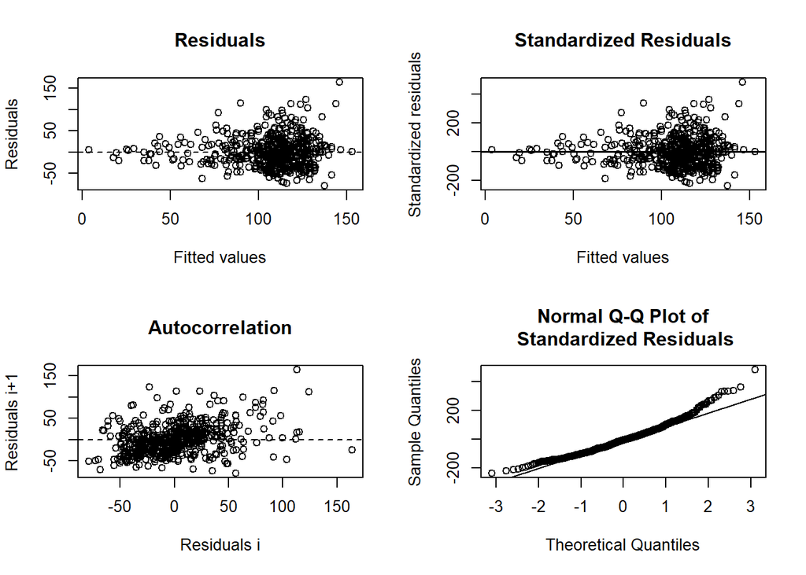

```
##
## ------
##  Shapiro-Wilk normality test
##
## data:  stdres
## W = 0.96689, p-value = 1.88e-09
##
##
## ------
```

```
##
##  Runs Test
##
## data:  as.factor(run)
## Standard Normal = -7.2531, p-value = 4.072e-13
## alternative hypothesis: two.sided
```

## predict and plot

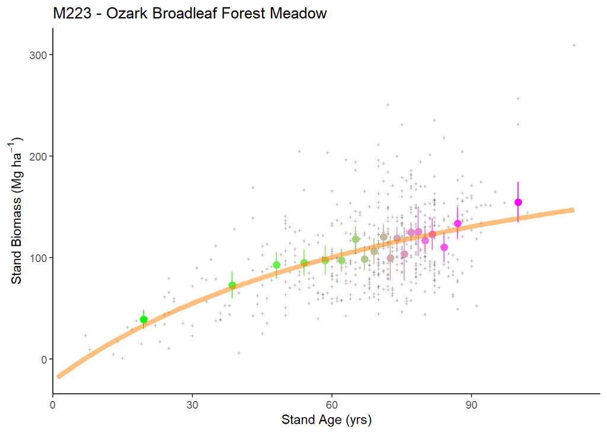

## plotting 2

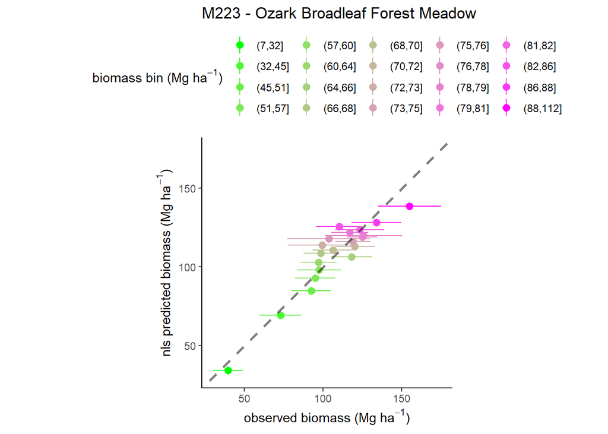

# M231 - Ouachita Mixed Forest

## model selection 1

```
## Error in nls(f_3, data = G_M231, start = c(ge = ge.start, phi = phi.start,  :
##   step factor 0.000488281 reduced below 'minFactor' of 0.000976562
## Analysis of Variance Table
##
## Model 1: B_plt_t1_MgHa ~ (1 + (MEASTIME_t2 - 1990) * ge/100) * A * STDAGE_t2/(k + STDAGE_t2)
## Model 2: B_plt_t1_MgHa ~ (1 + (MEASTIME_t2 - 1990) * ge/100) * (1 + phi * DeltaPDSI) * A * STDAGE_t2/(k + STDAGE_t2)
##   Res.Df Res.Sum Sq Df     Sum Sq F value Pr(>F)
## 1    580     129.95
## 2    579     129.95  1 0.00093207  0.0042 0.9486
##   model      AIC
## 1     1 5992.930
## 2     2 5994.926
## 3     3       NA
```

```
##
## Formula: B_plt_t1_MgHa ~ (1 + (MEASTIME_t2 - 1990) * ge/100) * A * STDAGE_t2/(k +
##     STDAGE_t2)
##
## Parameters:
##    Estimate Std. Error t value Pr(>|t|)
## ge  -0.3383     0.3696  -0.915   0.3604
## A  784.1898   383.8168   2.043   0.0415 *
## k  427.2862   228.1739   1.873   0.0616 .
## ---
## Signif. codes:  0 '***' 0.001 '**' 0.01 '*' 0.05 '.' 0.1 ' ' 1
##
## Residual standard error: 0.4733 on 580 degrees of freedom
##
## Number of iterations to convergence: 7
## Achieved convergence tolerance: 2.68e-06
##   (1 observation deleted due to missingness)
```

### summary

- simple model: fits
- phi model: fits
- phi-alpha model: does not fit

## model selection 2

```
## Error in numericDeriv(form[[3L]], names(ind), env, central = nDcentral) :
##   Missing value or an infinity produced when evaluating the model
## Error in numericDeriv(form[[3L]], names(ind), env, central = nDcentral) :
##   Missing value or an infinity produced when evaluating the model
## Analysis of Variance Table
##
## Model 1: B_plt_t1_MgHa ~ (1 + (MEASTIME_t2 - 1990) * ge/100) * A * STDAGE_t2/(k + STDAGE_t2)
## Model 2: B_plt_t1_MgHa ~ (1 + (MEASTIME_t2 - 1990) * ge/100) * (p * A + ((1 - p) * A * STDAGE_t2/(k + STDAGE_t2)))
##   Res.Df Res.Sum Sq Df Sum Sq F value  Pr(>F)
## 1    580     129.95
## 2    579     128.69  1 1.2646    5.69 0.01738 *
## ---
## Signif. codes:  0 '***' 0.001 '**' 0.01 '*' 0.05 '.' 0.1 ' ' 1
##   model      AIC
## 1     1 5992.930
## 2    1a 5989.228
## 3    1b       NA
## 4    1c       NA
```

```
##
## Formula: B_plt_t1_MgHa ~ (1 + (MEASTIME_t2 - 1990) * ge/100) * (p * A +
##     ((1 - p) * A * STDAGE_t2/(k + STDAGE_t2)))
##
## Parameters:
##     Estimate Std. Error t value Pr(>|t|)
## ge  -0.28669    0.37679  -0.761 0.447051
## A  309.26332   90.19678   3.429 0.000649 ***
## k  106.27445   51.40631   2.067 0.039146 *
## p   -0.07040    0.05438  -1.295 0.195992
## ---
## Signif. codes:  0 '***' 0.001 '**' 0.01 '*' 0.05 '.' 0.1 ' ' 1
##
## Residual standard error: 0.4714 on 579 degrees of freedom
##
## Number of iterations to convergence: 6
## Achieved convergence tolerance: 4.827e-06
##   (1 observation deleted due to missingness)
```

### summary

- add p model: fits
- add s model: does not fit
- add s+p model: does not fit

## plot residuals

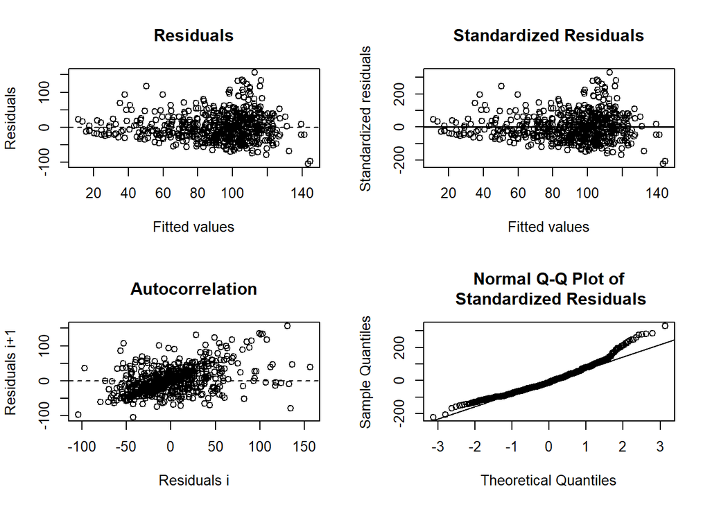

```
##
## ------
##  Shapiro-Wilk normality test
##
## data:  stdres
## W = 0.96317, p-value = 6.49e-11
##
##
## ------
```

```
##
##  Runs Test
##
## data:  as.factor(run)
## Standard Normal = -9.0056, p-value < 2.2e-16
## alternative hypothesis: two.sided
```

## predict and plot

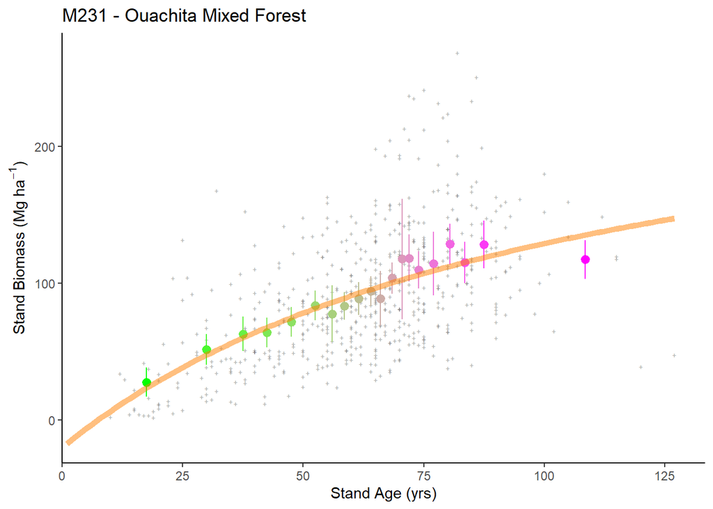

## plotting 2

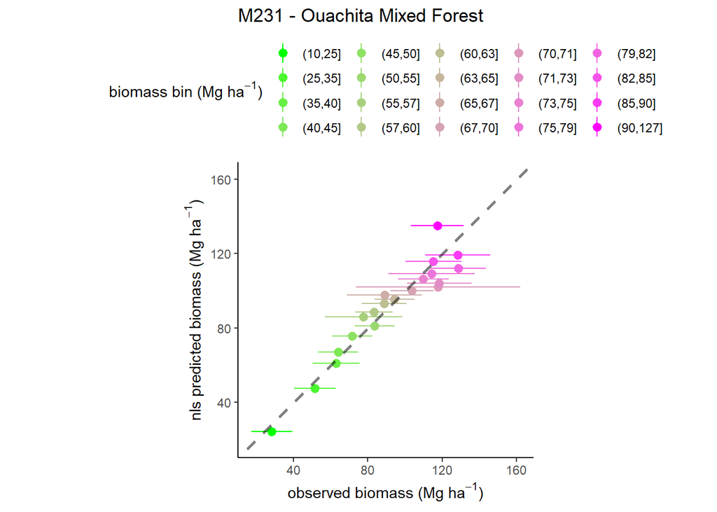

# M242 - Cascade Mixed Forest

## model selection 1

### summary

- simple model: does not fit
- phi model: does not fit
- phi-alpha model: does not fit

## model selection 2

### summary

- add p model: does not fit
- add s model: does not fit
- add s+p model: does not fit

## plot residuals

```
## [1] "cannot plot residuals"
```

## predict and plot

```
## [1] "cannot plot data with prediction"
```

## plotting 2

```
## [1] "cannot plot observed vs. predicted"
```

# M261 - Sierran Steppe - Mixed Forest - Coniferous Forest - Alpine Meadow

## model selection 1

### summary

- simple model: does not fit
- phi model: does not fit
- phi-alpha model: does not fit

## model selection 2

### summary

- add p model: does not fit
- add s model: does not fit
- add s+p model: does not fit

## plot residuals

```
## [1] "cannot plot residuals"
```

## predict and plot

```
## [1] "cannot plot data with prediction"
```

## plotting 2

[output not shown]

# M262 - California coastal range - coniferous forest - open woodland - shrub meadow

## Model selection 1

### summary

- simple model: does not fit
- phi model: does not fit
- phi-alpha model: does not fit

## model selection 2

### summary

- add p model: does not fit
- add s model: does not fit
- add s+p model: does not fit

## plot residuals

```
## [1] "cannot plot residuals"
```

- model can fit - but K is negative (only 19 observations) - model excluded

## predict and plot

```
## [1] "cannot plot data with prediction"
```

## plotting 2

# M313 - Arizona-New Mexico Mountains Semi-Desert - Open Woodland - Coniferous Forest - Alpine Meadow

## model selection 1

[output not shown]

[output not shown]

### summary

- simple model: does not fit
- phi model: does not fit
- phi-alpha model: does not fit

## model selection 2

### summary

- add p model: does not fit
- add s model: does not fit
- add s+p model: does not fit

## plot residuals

```
## [1] "cannot plot residuals"
```

## predict and plot

```
## [1] "cannot plot data with prediction"
```

## plotting 2

# M331 - Southern Rocky Mountain Steppe - Open Woodland - Coniferous Forest - Alpine Meadow

## model selection 1

[output not shown]

[output not shown]

### summary

- simple model: does not fit
- phi model: does not fit
- phi-alpha model: does not fit

## model selection 2

### summary

- add p model: does not fit
- add s model: does not fit
- add s+p model: does not fit

## plot residuals

```
## [1] "cannot plot residuals"
```

## predict and plot

```
## [1] "cannot plot data with prediction"
```

## plotting 2

# M332 - Middle Rocky Mountain Steppe - Coniferous Forest - Alpine Meadow

## model selection 1

### summary

- simple model: does not fit
- phi model: does not fit
- phi-alpha model: does not fit

## model selection 2

### summary

- add p model: does not fit
- add s model: does not fit
- add s+p model: does not fit

## plot residuals

```
## [1] "cannot plot residuals"
```

## predict and plot

```
## [1] "cannot plot data with prediction"
```

## plotting 2

# M333 - Northern Rocky Mountain Steppe - Coniferous Forest - Alpine Meadow

## model selection 1

```
## Error in if (any(nEQ <- vNms != make.names(vNms))) vNms[nEQ] <- paste0("`",  :
##   missing value where TRUE/FALSE needed
## Error in if (any(nEQ <- vNms != make.names(vNms))) vNms[nEQ] <- paste0("`",  :
##   missing value where TRUE/FALSE needed
## Error in if (any(nEQ <- vNms != make.names(vNms))) vNms[nEQ] <- paste0("`",  :
##   missing value where TRUE/FALSE needed
##   model AIC
## 1     1  NA
## 2     2  NA
## 3     3  NA
```

```
## Error in h(simpleError(msg, call)) :
##   error in evaluating the argument 'object' in selecting a method for function 'summary': object 'nls_M333.' not found
```

### summary

- simple model: does not fit
- phi model: does not fit
- phi-alpha model: does not fit

## model selection 2

### summary

- add p model: does not fit
- add s model: does not fit
- add s+p model: does not fit

## plot residuals

```
## [1] "cannot plot residuals"
```

## predict and plot

```
## [1] "cannot plot data with prediction"
```

## plotting 2

# M334 - Black Hills Coniferous Forest

## model selection 1

```
## Analysis of Variance Table
##
## Model 1: B_plt_t1_MgHa ~ (1 + (MEASTIME_t2 - 1990) * ge/100) * A * STDAGE_t2/(k + STDAGE_t2)
## Model 2: B_plt_t1_MgHa ~ (1 + (MEASTIME_t2 - 1990) * ge/100) * (1 + phi * DeltaPDSI) * A * STDAGE_t2/(k + STDAGE_t2)
## Model 3: B_plt_t1_MgHa ~ (1 + (MEASTIME_t2 - 1990) * ge/100) * (1 + phi * DeltaPDSI) * (1 - alpha * B_L_prop) * A * STDAGE_t2/(k + STDAGE_t2)
##   Res.Df Res.Sum Sq Df  Sum Sq F value  Pr(>F)
## 1    224     83.217
## 2    223     83.104  1 0.11318  0.3037 0.58212
## 3    222     81.253  1 1.85093  5.0571 0.02551 *
## ---
## Signif. codes:  0 '***' 0.001 '**' 0.01 '*' 0.05 '.' 0.1 ' ' 1
##   model      AIC
## 1     1 2283.212
## 2     2 2284.903
## 3     3 2281.790
```

```
##
## Formula: B_plt_t1_MgHa ~ (1 + (MEASTIME_t2 - 1990) * ge/100) * (1 + phi *
##     DeltaPDSI) * (1 - alpha * B_L_prop) * A * STDAGE_t2/(k +
##     STDAGE_t2)
##
## Parameters:
##        Estimate Std. Error t value Pr(>|t|)
## ge     -0.86102    0.65765  -1.309 0.191805
## phi     0.04473    0.04412   1.014 0.311826
## alpha  -0.59663    0.28148  -2.120 0.035146 *
## A     116.64629   29.63907   3.936 0.000111 ***
## k      58.59612   25.53677   2.295 0.022692 *
## ---
## Signif. codes:  0 '***' 0.001 '**' 0.01 '*' 0.05 '.' 0.1 ' ' 1
##
## Residual standard error: 0.605 on 222 degrees of freedom
##
## Number of iterations to convergence: 5
## Achieved convergence tolerance: 8.185e-06
##   (1 observation deleted due to missingness)
```

### summary

- simple model: fits
- phi model: fits
- phi-alpha model: fits

## model selection 2

```
## Error in nls(get(paste("f_", Mod.Sel1, "b", sep = "")), data = G_M334,  :
##   number of iterations exceeded maximum of 50
## Analysis of Variance Table
##
## Model 1: B_plt_t1_MgHa ~ (1 + (MEASTIME_t2 - 1990) * ge/100) * (1 + phi * DeltaPDSI) * (1 - alpha * B_L_prop) * A * STDAGE_t2/(k + STDAGE_t2)
## Model 2: B_plt_t1_MgHa ~ (1 + (MEASTIME_t2 - 1990) * ge/100) * (1 + phi * DeltaPDSI) * (1 - alpha * B_L_prop) * (p * A + ((1 - p) * A * STDAGE_t2/(k + STDAGE_t2)))
## Model 3: B_plt_t1_MgHa ~ (1 + (MEASTIME_t2 - 1990) * ge/100) * (1 + phi * DeltaPDSI) * (1 - alpha * B_L_prop) * (p * A + ((1 - p) * A * STDAGE_t2^s/(k^s + STDAGE_t2^s)))
##   Res.Df Res.Sum Sq Df  Sum Sq F value Pr(>F)
## 1    222     81.253
## 2    221     80.320  1 0.93244  2.5656 0.1106
## 3    220     79.914  1 0.40595  1.1176 0.2916
##   model     AIC
## 1     3 2281.79
## 2    3a 2281.17
## 3    3b      NA
## 4    3c 2282.02
```

```
##
## Formula: B_plt_t1_MgHa ~ (1 + (MEASTIME_t2 - 1990) * ge/100) * (1 + phi *
##     DeltaPDSI) * (1 - alpha * B_L_prop) * (p * A + ((1 - p) *
##     A * STDAGE_t2/(k + STDAGE_t2)))
##
## Parameters:
##         Estimate Std. Error t value Pr(>|t|)
## ge      -0.90520    0.63949  -1.416   0.1583
## phi      0.04015    0.04391   0.914   0.3615
## alpha   -0.51902    0.27517  -1.886   0.0606 .
## A      350.18610  954.62275   0.367   0.7141
## k      643.99989 2408.78667   0.267   0.7894
## p        0.08890    0.20888   0.426   0.6708
## ---
## Signif. codes:  0 '***' 0.001 '**' 0.01 '*' 0.05 '.' 0.1 ' ' 1
##
## Residual standard error: 0.6029 on 221 degrees of freedom
##
## Number of iterations to convergence: 13
## Achieved convergence tolerance: 6.906e-06
##   (1 observation deleted due to missingness)
```

### summary

- add p model: fits
- add s model: does not fit
- add s+p model: fits

## plot residuals

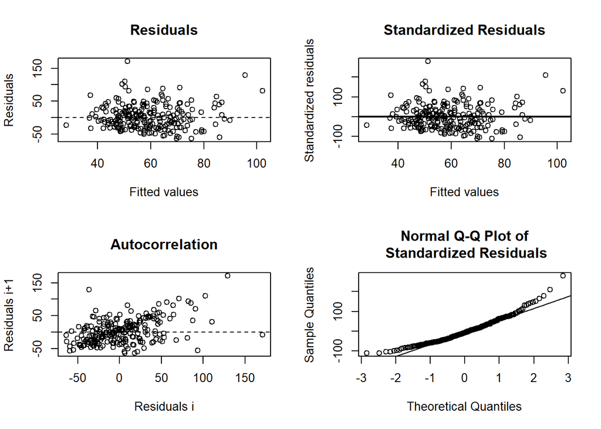

```
##
## ------
##  Shapiro-Wilk normality test
##
## data:  stdres
## W = 0.95242, p-value = 8.169e-07
##
##
## ------
```

```
##
##  Runs Test
##
## data:  as.factor(run)
## Standard Normal = -4.2479, p-value = 2.158e-05
## alternative hypothesis: two.sided
```

## predict and plot

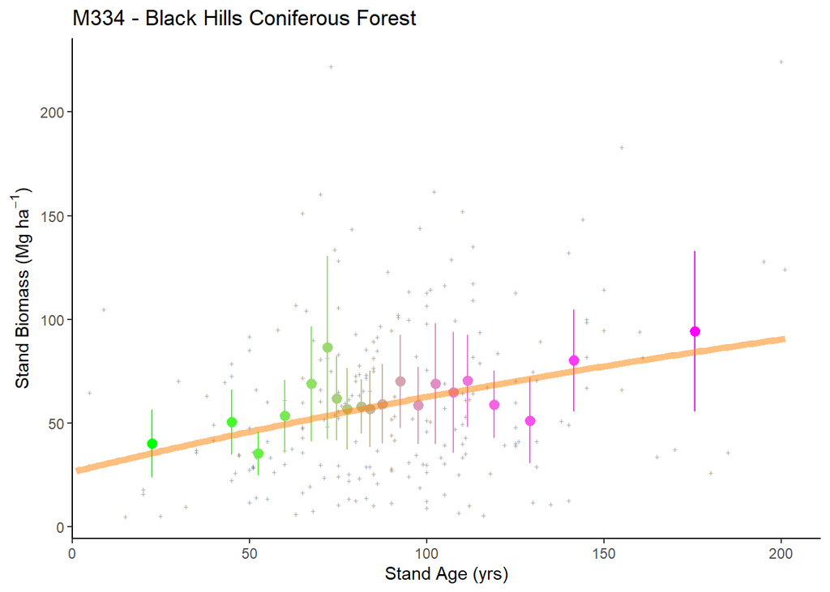

## plotting 2

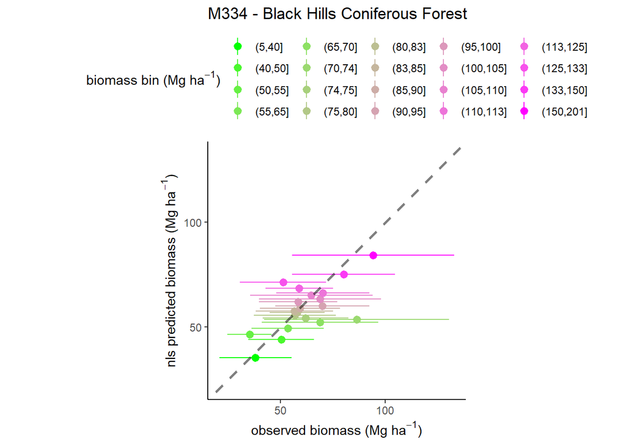

# M341 - Nevada-Utah Mountains Semi-Desert - Coniferous Forest - Alpine Meadow

## model selection 1

```
## Error in if (any(nEQ <- vNms != make.names(vNms))) vNms[nEQ] <- paste0("`",  :
##   missing value where TRUE/FALSE needed
## Error in if (any(nEQ <- vNms != make.names(vNms))) vNms[nEQ] <- paste0("`",  :
##   missing value where TRUE/FALSE needed
## Error in if (any(nEQ <- vNms != make.names(vNms))) vNms[nEQ] <- paste0("`",  :
##   missing value where TRUE/FALSE needed
##   model AIC
## 1     1  NA
## 2     2  NA
## 3     3  NA
```

```
## Error in h(simpleError(msg, call)) :
##   error in evaluating the argument 'object' in selecting a method for function 'summary': object 'nls_M341.' not found
```

### summary

- simple model: does not fit
- phi model: does not fit
- phi-alpha model: does not fit

## model selection 2

### summary

- add p model: does not fit
- add s model: does not fit
- add s+p model: does not fit

## plot residuals

```
## [1] "cannot plot residuals"
```

## predict and plot

```
## [1] "cannot plot data with prediction"
```

## plotting 2

# Fitted parameters

## Best / selected models by ecoprovince

| Code | Ecoregion | Sel.Mod |
| --- | --- | --- |
| 211 | Northeastern Mixed Forest | 3 |
| 212 | Laurentian Mixed Forest | 3b |
| 221 | Eastern Broadleaf Forest | 3a |
| 222 | Midwest Broadleaf Forest | 3 |
| 223 | Central Interior Broadleaf Forest | 1a |
| 231 | Southeastern Mixed Forest | 1a |
| 232 | Outer Coastal Plain Mixed Forest | 3a |
| 234 | Lower Mississippi Riverine Forest | NA |
| 242 | Pacific Lowland Mixed Forest | NA |
| 251 | Prairie Parkland (Temperate) | 1 |
| 255 | Prairie Parkland (Subtropical) | 1 |
| 261 | California Coastal Chaparral Forest and Shrub | NA |
| 262 | California Dry Steppe | NA |
| 263 | California Coastal Steppe - Mixed Forest and Redwood Forest | NA |
| 313 | Colorado Plateau Semi-Desert | NA |
| 315 | Southwest Plateau and Plains Dry Steppe and Shrub | NA |
| 321 | Chihuahuan Semi-Desert | NA |
| 322 | American Semidesert and Desert | NA |
| 331 | Great Plains/Palouse Dry Steppe | 1 |
| 332 | Great Plains Steppe | 1 |
| 341 | Intermountain Semi-Desert and Desert | NA |
| 342 | Intermountain Semi-Desert | NA |
| 411 | Everglades | NA |
| M211 | Adirondack-New England Mixed forest - Coniferous Forest - Alpine Meadow | 3 |
| M221 | Central Appalachian Broadleaf Forest - Coniferous Forest - Meadow | 2a |
| M223 | Ozark Broadleaf Forest Meadow | 2a |
| M231 | Ouachita Mixed Forest | 1a |
| M242 | Cascade Mixed Forest | NA |
| M261 | Sierran Steppe - Mixed Forest - Coniferous Forest - Alpine Meadow | NA |
| M262 | California Coastal Range Coniferous Forest - Open Woodland - Shrub - Meadow | NA |
| M313 | Arizona-New Mexico Mountains Semi-Desert - Open Woodland - Coniferous Forest - Alpine Meadow | NA |
| M331 | Southern Rocky Mountain Steppe - Open Woodland - Coniferous Forest - Alpine Meadow | NA |
| M332 | Middle Rocky Mountain Steppe - Coniferous Forest - Alpine Meadow | NA |
| M333 | Northern Rocky Mountain Steppe - Coniferous Forest - Alpine Meadow | NA |
| M334 | Black Hills Coniferous Forest | 3a |
| M341 | Nevada-Utah Mountains Semi-Desert - Coniferous Forest - Alpine Meadow | NA |

## table by ecoprovince

| Code | Ecoregion | region | n.obs | n.plots | ge | ge.2.5 | ge.97.5 | phi | phi.2.5 | phi.97.5 | alpha | alpha.2.5 | alpha.97.5 | A | A.2.5 | A.97.5 | k | k.2.5 | k.97.5 |
| --- | --- | --- | --- | --- | --- | --- | --- | --- | --- | --- | --- | --- | --- | --- | --- | --- | --- | --- | --- |
| 211 | Northeastern Mixed Forest | east | 3714 | 1857 | 0.5345813 | -0.0178633 | 1.0870259 | 0.0100112 | -0.0075692 | 0.0275916 | 0.5620206 | 0.3846950 | 0.7393462 | 577.9143 | 359.70089 | 796.1277 | 291.47646 | 149.23411 | 433.71880 |
| 212 | Laurentian Mixed Forest | east | 9658 | 4829 | 0.2007845 | -0.0829230 | 0.4844921 | -0.0035364 | -0.0145649 | 0.0074921 | 0.1579932 | 0.0448546 | 0.2711319 | 138.6666 | 123.75786 | 153.5753 | 54.57902 | 47.16139 | 61.99665 |
| 221 | Eastern Broadleaf Forest | east | 4386 | 2193 | 0.1250396 | -0.1897944 | 0.4398735 | -0.0038660 | -0.0168308 | 0.0090987 | -0.0335068 | -0.1609497 | 0.0939361 | 564.7828 | 425.82214 | 703.7435 | 204.21254 | 135.17502 | 273.25006 |
| 222 | Midwest Broadleaf Forest | east | 2576 | 1288 | -0.1695402 | -0.7112665 | 0.3721861 | 0.0433892 | 0.0132966 | 0.0734818 | 0.1772915 | -0.0000265 | 0.3546095 | 6364.4877 | -16817.32996 | 29546.3054 | 4373.54382 | -11726.46569 | 20473.55333 |
| 223 | Central Interior Broadleaf Forest | east | 5024 | 2512 | -0.0895319 | -0.3114157 | 0.1323519 | NA | NA | NA | NA | NA | NA | 274.3576 | 238.04636 | 310.6689 | 89.06450 | 67.72406 | 110.40494 |
| 231 | Southeastern Mixed Forest | east | 5952 | 2976 | 0.3020117 | 0.0457376 | 0.5582857 | NA | NA | NA | NA | NA | NA | 619.6175 | 470.00222 | 769.2328 | 234.37168 | 163.24682 | 305.49653 |
| 232 | Outer Coastal Plain Mixed Forest | east | 6120 | 3060 | 0.1274195 | -0.1910529 | 0.4458919 | 0.0303503 | 0.0132489 | 0.0474516 | 0.1469205 | 0.0184468 | 0.2753941 | 707.3341 | 473.99675 | 940.6714 | 283.00290 | 169.01526 | 396.99055 |
| 234 | Lower Mississippi Riverine Forest | east | 640 | 320 | NA | NA | NA | NA | NA | NA | NA | NA | NA | NA | NA | NA | NA | NA | NA |
| 242 | Pacific Lowland Mixed Forest | pacific | 0 | 0 | NA | NA | NA | NA | NA | NA | NA | NA | NA | NA | NA | NA | NA | NA | NA |
| 251 | Prairie Parkland (Temperate) | east | 1112 | 556 | 0.0139510 | -0.6109050 | 0.6388070 | NA | NA | NA | NA | NA | NA | 310.8219 | 211.80453 | 409.8393 | 146.67835 | 91.28904 | 202.06766 |
| 255 | Prairie Parkland (Subtropical) | pacific | 382 | 191 | -0.6916122 | -1.5787260 | 0.1955016 | NA | NA | NA | NA | NA | NA | 332.1951 | 100.28163 | 564.1085 | 144.63506 | 24.53467 | 264.73545 |
| 261 | California Coastal Chaparral Forest and Shrub | pacific | 0 | 0 | NA | NA | NA | NA | NA | NA | NA | NA | NA | NA | NA | NA | NA | NA | NA |
| 262 | California Dry Steppe | pacific | 0 | 0 | NA | NA | NA | NA | NA | NA | NA | NA | NA | NA | NA | NA | NA | NA | NA |
| 263 | California Coastal Steppe - Mixed Forest and Redwood Forest | pacific | 0 | 0 | NA | NA | NA | NA | NA | NA | NA | NA | NA | NA | NA | NA | NA | NA | NA |
| 313 | Colorado Plateau Semi-Desert | interior west | 0 | 0 | NA | NA | NA | NA | NA | NA | NA | NA | NA | NA | NA | NA | NA | NA | NA |
| 315 | Southwest Plateau and Plains Dry Steppe and Shrub | interior west | 0 | 0 | NA | NA | NA | NA | NA | NA | NA | NA | NA | NA | NA | NA | NA | NA | NA |
| 321 | Chihuahuan Semi-Desert | interior west | 0 | 0 | NA | NA | NA | NA | NA | NA | NA | NA | NA | NA | NA | NA | NA | NA | NA |
| 322 | American Semidesert and Desert | interior west | 0 | 0 | NA | NA | NA | NA | NA | NA | NA | NA | NA | NA | NA | NA | NA | NA | NA |
| 331 | Great Plains/Palouse Dry Steppe | interior west | 100 | 50 | -0.2250514 | -3.7036822 | 3.2535793 | NA | NA | NA | NA | NA | NA | 106.2184 | -83.87799 | 296.3147 | 74.59783 | -147.61130 | 296.80695 |
| 332 | Great Plains Steppe | interior west | 124 | 62 | 1.1333775 | -4.2125129 | 6.4792680 | NA | NA | NA | NA | NA | NA | 388.3361 | -983.15265 | 1759.8249 | 395.48226 | -1084.43410 | 1875.39862 |
| 341 | Intermountain Semi-Desert and Desert | interior west | 0 | 0 | NA | NA | NA | NA | NA | NA | NA | NA | NA | NA | NA | NA | NA | NA | NA |
| 342 | Intermountain Semi-Desert | interior west | 2 | 1 | NA | NA | NA | NA | NA | NA | NA | NA | NA | NA | NA | NA | NA | NA | NA |
| 411 | Everglades | east | 60 | 30 | NA | NA | NA | NA | NA | NA | NA | NA | NA | NA | NA | NA | NA | NA | NA |
| M211 | Adirondack-New England Mixed forest - Coniferous Forest - Alpine Meadow | east | 3948 | 1974 | 0.6913865 | 0.2272281 | 1.1555449 | 0.0308831 | 0.0144005 | 0.0473658 | 0.1377284 | -0.0286027 | 0.3040595 | 848.2793 | 579.68723 | 1116.8713 | 550.63132 | 369.09819 | 732.16445 |
| M221 | Central Appalachian Broadleaf Forest - Coniferous Forest - Meadow | east | 4550 | 2275 | 0.3436539 | 0.0798928 | 0.6074150 | -0.0353616 | -0.0476575 | -0.0230656 | NA | NA | NA | 301.0915 | 265.64817 | 336.5348 | 78.36601 | 60.60018 | 96.13184 |
| M223 | Ozark Broadleaf Forest Meadow | east | 522 | 261 | -1.0446328 | -1.4633041 | -0.6259616 | 0.0993211 | 0.0500809 | 0.1485613 | NA | NA | NA | 350.0944 | 193.94596 | 506.2428 | 88.61077 | 12.89292 | 164.32862 |
| M231 | Ouachita Mixed Forest | east | 584 | 292 | -0.2866863 | -1.0267343 | 0.4533617 | NA | NA | NA | NA | NA | NA | 309.2633 | 132.11056 | 486.4161 | 106.27445 | 5.30889 | 207.24002 |
| M242 | Cascade Mixed Forest | pacific | 6 | 3 | NA | NA | NA | NA | NA | NA | NA | NA | NA | NA | NA | NA | NA | NA | NA |
| M261 | Sierran Steppe - Mixed Forest - Coniferous Forest - Alpine Meadow | pacific | 0 | 0 | NA | NA | NA | NA | NA | NA | NA | NA | NA | NA | NA | NA | NA | NA | NA |
| M262 | California Coastal Range Coniferous Forest - Open Woodland - Shrub - Meadow | interior west | 0 | 0 | NA | NA | NA | NA | NA | NA | NA | NA | NA | NA | NA | NA | NA | NA | NA |
| M313 | Arizona-New Mexico Mountains Semi-Desert - Open Woodland - Coniferous Forest - Alpine Meadow | interior west | 0 | 0 | NA | NA | NA | NA | NA | NA | NA | NA | NA | NA | NA | NA | NA | NA | NA |
| M331 | Southern Rocky Mountain Steppe - Open Woodland - Coniferous Forest - Alpine Meadow | interior west | 0 | 0 | NA | NA | NA | NA | NA | NA | NA | NA | NA | NA | NA | NA | NA | NA | NA |
| M332 | Middle Rocky Mountain Steppe - Coniferous Forest - Alpine Meadow | interior west | 2 | 1 | NA | NA | NA | NA | NA | NA | NA | NA | NA | NA | NA | NA | NA | NA | NA |
| M333 | Northern Rocky Mountain Steppe - Coniferous Forest - Alpine Meadow | interior west | 0 | 0 | NA | NA | NA | NA | NA | NA | NA | NA | NA | NA | NA | NA | NA | NA | NA |
| M334 | Black Hills Coniferous Forest | interior west | 228 | 114 | -0.9051982 | -2.1654760 | 0.3550796 | 0.0401542 | -0.0463862 | 0.1266945 | -0.5190209 | -1.0613133 | 0.0232714 | 350.1861 | -1531.14267 | 2231.5149 | 643.99989 | -4103.13154 | 5391.13131 |
| M341 | Nevada-Utah Mountains Semi-Desert - Coniferous Forest - Alpine Meadow | interior west | 0 | 0 | NA | NA | NA | NA | NA | NA | NA | NA | NA | NA | NA | NA | NA | NA | NA |

## plot ge

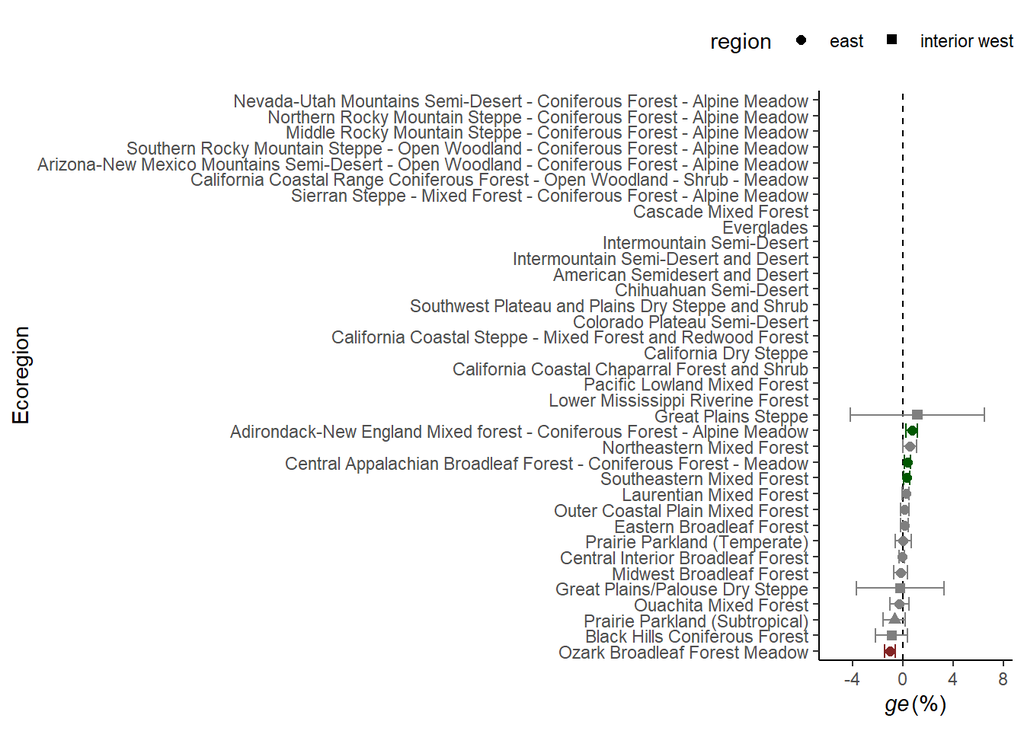

### map

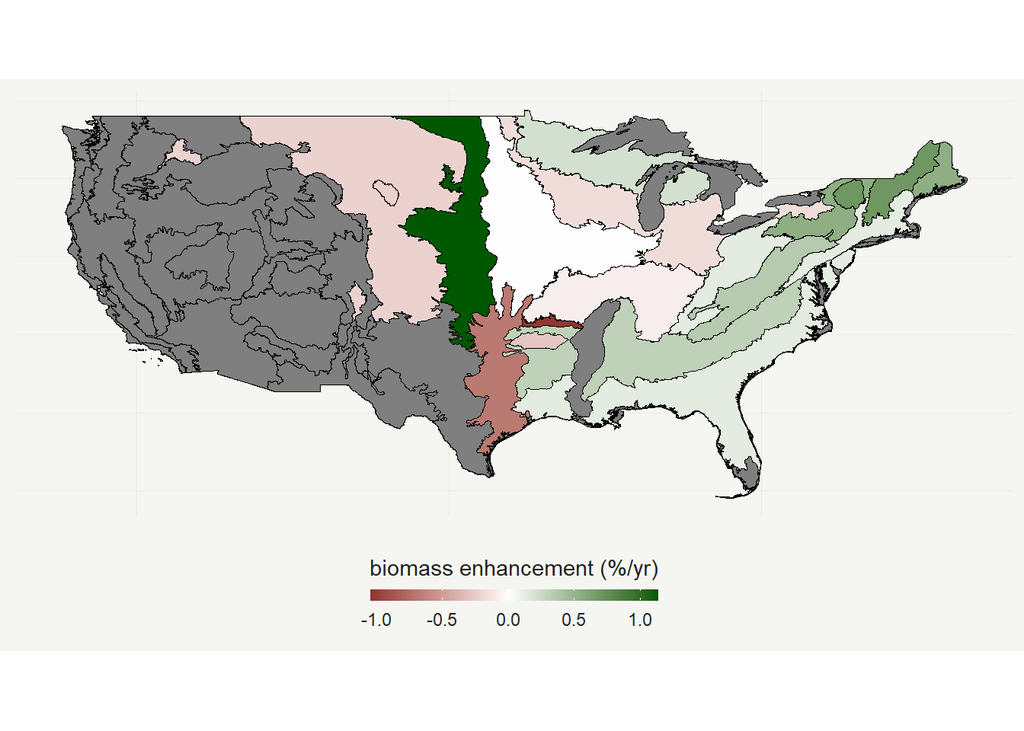

### map #2

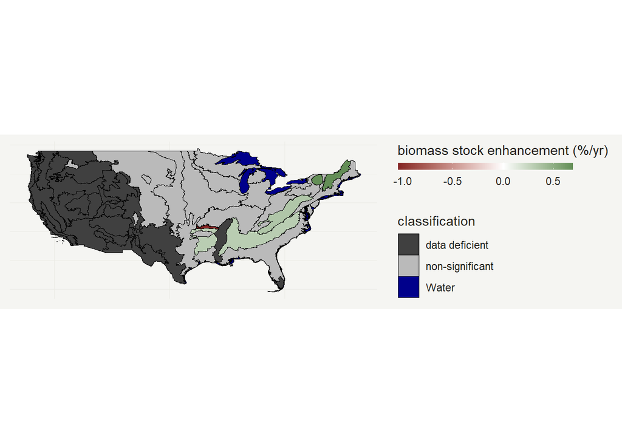

## plot phi (effect of DeltaPDSI)

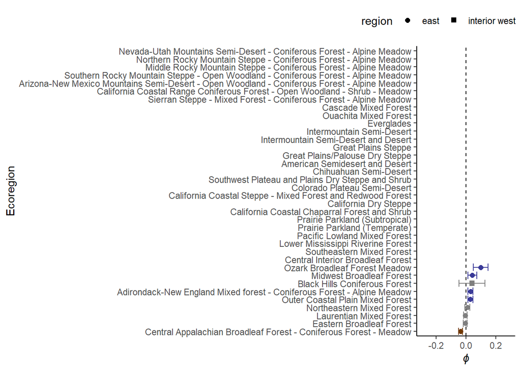

## plot alpha (biomass compensation effect)

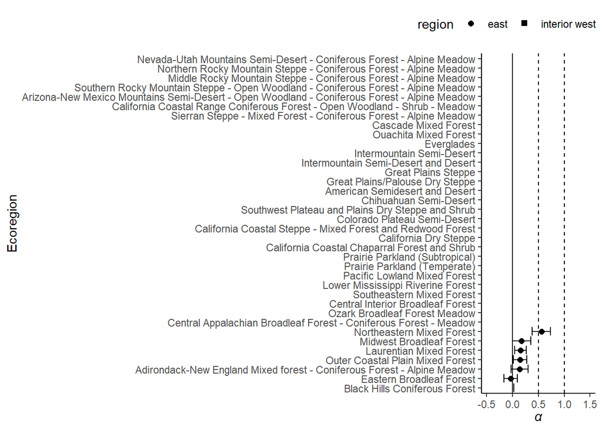

## plot A (asymptote of B)

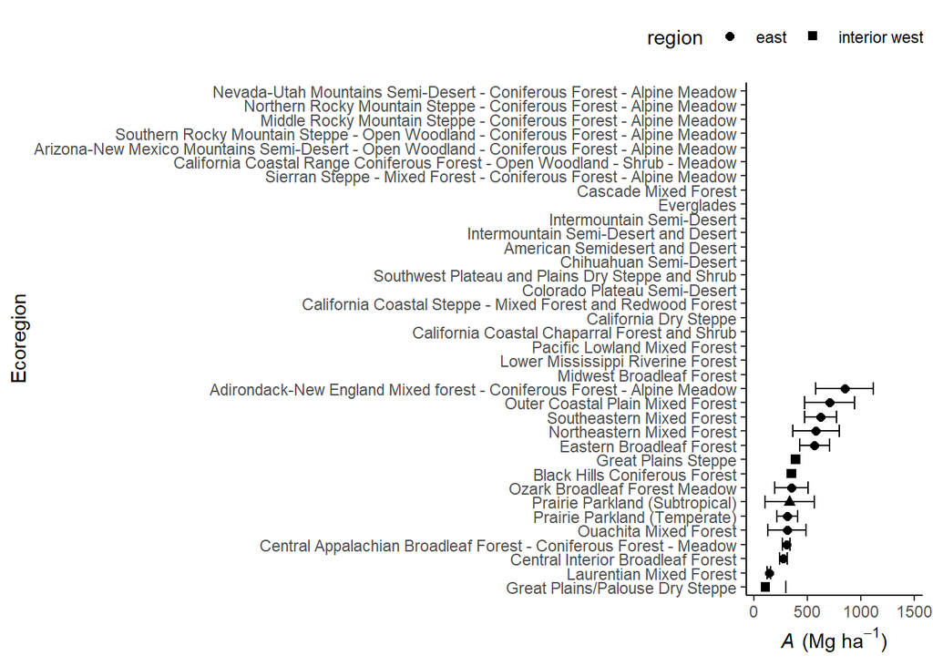

## plot k (stand age at half biomass asymptote)

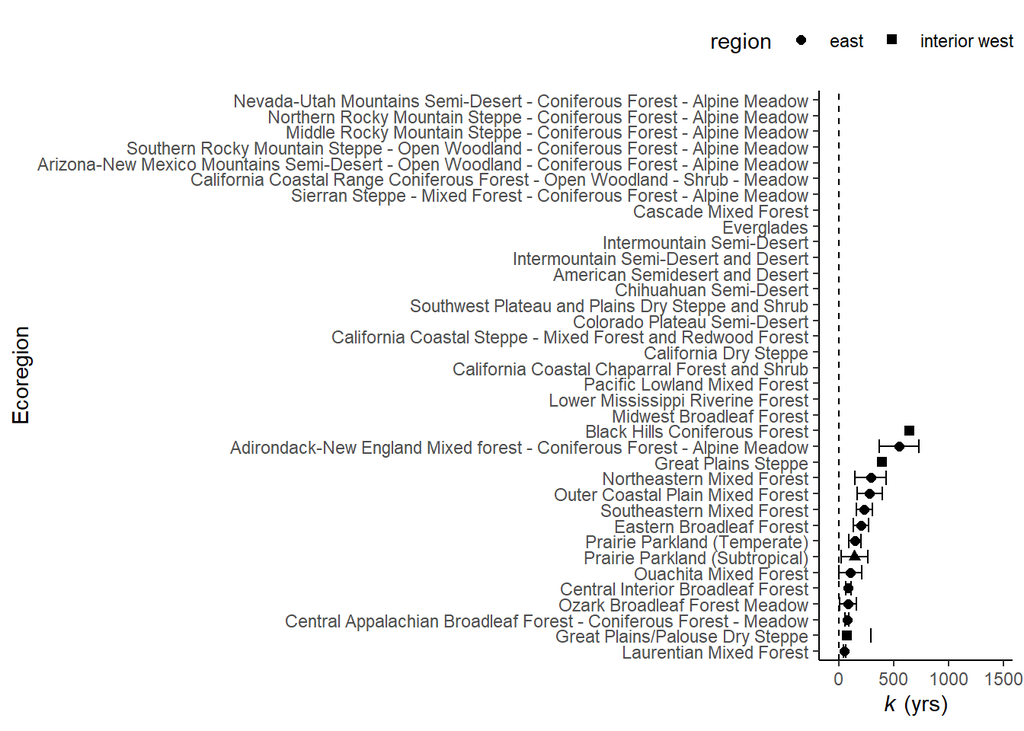

# Caclulations - weighted averages

## ge (stand biomass enhancement factor in % 2000-2021)

```
##          region weighted.ge
## 1     entire US   0.1893205
## 2       pacific  -0.6809172
## 3          east   0.1998092
## 4 interior west  -0.1937533
```

## phi (effect of DeltaPDSI)

```
##          region weighted.phi
## 1     entire US  0.006150468
## 2       pacific  0.000000000
## 3          east  0.006069312
## 4 interior west  0.020077087
```

## alpha (biomass compensation effect)

```
##          region weighted.alpha
## 1     entire US      0.1056058
## 2       pacific      0.0000000
## 3          east      0.1098532
## 4 interior west     -0.2595105
```

## A (asymptote of forest biomass in Mg/ha)

```
##          region weighted.A
## 1     entire US   753.5998
## 2       pacific   327.0580
## 3          east   761.1854
## 4 interior west     0.0000
```

## K (stand age at half maturation in years)

```
##          region weighted.k
## 1     entire US   410.6757
## 2       pacific   142.3984
## 3          east   412.4779
## 4 interior west   445.9025
```

# Calculations - weighted averages subsetted to 15 ecoprovinces

- 211, 212, 221, 223, 231, 232, 234, 251, M211, M221, M223, M231, M242, M261, M332,

## ge

```
##          region weighted.ge
## 1     entire US   0.2206200
## 2       pacific   0.0000000
## 3          east   0.2206582
## 4 interior west   0.0000000
```

## phi

```
##          region weighted.phi
## 1     entire US  0.003996083
## 2       pacific  0.000000000
## 3          east  0.003996775
## 4 interior west  0.000000000
```

## alpha

```
##          region weighted.alpha
## 1     entire US      0.1062181
## 2       pacific      0.0000000
## 3          east      0.1062365
## 4 interior west      0.0000000
```